# Time Series. Stationary Processes (ARMA Models)

### General process

**Gaussian process** $\{X_t\}_{t=1,\cdots,n}$

Assuming $X=(X_t)_{t=1\dots T} \sim$ Multivariate Normal/Gaussian distribution

- Mean vector:
  $$E(X)=\mu=(\mu_1,\cdots,\mu_T)'$$
- Covariance matrix ($T$x$T$):
  $$V(X)=\Sigma=[\gamma(X_t,X_s)]_{t,s} \qquad
  t,s=1,\cdots,T$$
- And the multivariate Normal density function can be written as
  $$f_X(x;\mu,\Sigma)=(2\pi)^{-n/2}|\Sigma|^{-1/2}exp\{-(x-\mu)\Sigma^{-1}(x-\mu)/2\}$$
  where $|\Sigma| \equiv$ det($\Sigma$)

## Stationary process (Weakly stationary)

$\{X_t\}_{t=1,\cdots,n}$

- Mean Function:
  $$\mu(t)=\mu$$
- Variance Function:
  $$\sigma_X^2(t)=\gamma(t,t)=E[(X_t-\mu_t)^2]=\gamma(0)$$
- Autocovariance Function:
  $$\gamma(s,t)=E[(X_s-\mu_s)(X_t-\mu_t)]=\gamma(|s-t|)$$

### Mathematical Models

**Linear Stochastic model for a time series:**

Lets assume $\mu=0$ to simplify the notation. If $\mu\neq 0$, just consider $X'_t=X_t-\mu$ which is centered around 0.

$$X_t=\phi_1 X_{t-1}+\phi_2
X_{t-2}+...+\phi_p X_{t-p}+\theta_1 Z_{t-1}+\theta_2
Z_{t-2}+...+\theta_q Z_{t-q}+Z_t$$
$$Z_t\sim WN(0,\sigma^2_Z)$$
Parameters:
$$\phi_1,\phi_2,...,\phi_p,\theta_1,\theta_2,...\theta_q
\in \mathbf{R}\quad \sigma^2_Z\in \mathbf{R}^{+}$$
The variable at time $t$ is a linear combination of past observations and disturbances plus a new disturbance independent form the past

### AR(p) models

A **pth-order autoregressive model**, or AR(p), takes the form:

$$X_t=\phi_1 X_{t-1}+\phi_2
X_{t-2}+\cdots+\phi_p X_{t-p}+Z_t$$

Using the charasteristic polynomial of the AR part:

$$(1-\phi_1 B-\phi_2 B^2-\cdots+\phi_p
B^p) X_t=Z_t$$

An **AR(p)** model is a regression model with lagged values of the dependent variable in the independent variable positions, hence the name **Auto-Regressive model**.

Note:

- If $\mu \ne 0$, then

$$(X_t-\mu)=\phi_1(X_{t-1}-\mu)+\cdots+\phi_p(X_{t-p}-\mu)+Z_t$$

or adding a constant:
$$X_t=\alpha+\phi_1 X_{t-1}+\cdots+\phi_p X_{t-p}+z_t$$

where the constant term is:

$$\alpha = \mu
(1-\phi_1-\cdots-\phi_p)$$

Or a more concise expression:

$$\phi_p(B)(X_t-\mu)=Z_t$$
where $\phi(B)=(1-\phi_1B-\cdots-\phi_p B^p)$ is the characteristic autoregressive polynomial of order $p$.

### AR(1) models

**AR(1)** process, considering $\mu = 0$:

$$(1-\phi B)X_t=Z_t, \quad Z_t\sim
N(0,\sigma_Z^2)$$

Or equivalently:

$$X_t=\phi X_{t-1}+Z_t, \quad Z_t\sim
N(0,\sigma_Z^2)$$

#### **Autocovariance function**:

$$\gamma(0)=E[X_t^2]=E[(\phi
X_{t-1}+Z_t)^2]=\phi^2 E[X_{t-1}^2]+2E[X_{t-1}Z_t]+E[Z_t^2]=$$
$$=\phi^2 \gamma(0)+0+\sigma_Z^2 \Rightarrow
\gamma(0)=\frac{\sigma_Z^2}{1-\phi^2}$$
$$\gamma(1)=E[X_t X_{t-1}]=E[(\phi X_{t-1}+Z_t)
X_{t-1}]=\phi E[X_{t-1}^2]+E[Z_tX_{t-1})]=\phi \gamma(0)$$
$$:\qquad:\qquad:$$
$$\gamma(h)=E[X_t X_{t-h}]=E[(\phi X_{t-1}+Z_t)
X_{t-h}]=\phi E[X_{t-1}X_{t-h}]+E[Z_tX_{t-h})]=\phi \gamma(h-1)$$
$$\gamma(h)=\phi \gamma(h-1)=\phi^2
\gamma(h-2)=\dots=\phi^h\gamma(0)$$
Reminder:

The noise at time $t$ is independent of the past observations: $E[Z_t X_s]=0 \quad s< t$ and $E[Z_t X_t]=E[Z_t^2]=\sigma_Z^2$

The noises are independent of each other: $E[Z_t Z_s]=0 \quad s\neq t$.

#### **Autocorrelation function**:

$$\rho(1)=\frac{\gamma(1)}{\gamma(0)}=\phi$$
$$:\qquad:\qquad:$$
$$\rho(h)=\frac{\gamma(h)}{\gamma(0)}=\phi^h$$
Recursion: $\rho(h)=\phi \rho(h-1)$

#### **Partial Autocorrelation function**:

True Model: $X_t=\phi X_{t-1}+Z_t$

for $k=1$:
$$X_t=\phi_{1,1} X_{t-1}+Z_t \Rightarrow
\phi_{1,1}=\phi$$

for $k=2$:
$$X_t=\phi_{1,2} X_{t-1}+\phi_{2,2} X_{t-2}+Z_t
\Rightarrow \phi_{2,2}=0$$

for $k=3$:
$$X_t=\phi_{1,3} X_{t-1}+\phi_{2,3}
X_{t-2}+\phi_{3,3} X_{t-3}+Z_t \Rightarrow \phi_{3,3}=0$$

$$:\qquad:\qquad:$$
$$\phi_{h,h}=0 \quad h>1$$

#### **Patterns in ACF/PACF**:

**AR(1)** process: $(1-\phi B)X_t=Z_t$}

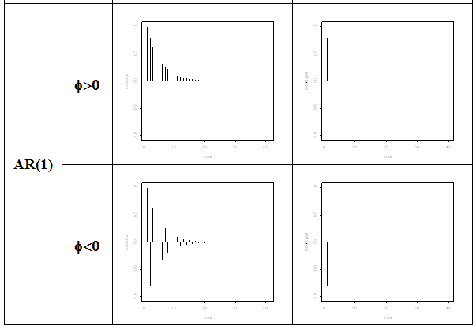

### AR(2) models

**AR(2)** process: $(1-\phi_1 B-\phi_2 B^2)X_t=Z_t$}

Considering $\mu = 0$, then
$$X_t=\phi_1 X_{t-1}+\phi_2 X_{t-2}+Z_t \quad
Z_t\sim N(0,\sigma_Z^2)$$

#### **Autocovariance function**:

$$\gamma(0)=E[X_t^2]=E[(\phi_1
X_{t-1}+\phi_2
X_{t-2}+Z_t)X_t]=\phi_1E[X_{t-1}X_t]+\phi_2E[X_{t-2}X_t]+E[Z_tX_t]$$
$$\gamma(0)=\phi_1\gamma(1)+\phi_2
\gamma(2)+\sigma_z^2$$

$$\gamma(1)=E[X_t X_{t-1}]=E[(\phi_1
X_{t-1}+\phi_2 X_{t-2}+Z_t)X_{t-1}]=\phi_1E[X_{t-1}^2]+\phi_2
E[X_{t-2}X_{t-1}]+E[Z_t X_{t-1}]$$
$$\gamma(1)=\phi_1\gamma(0)+\phi_2
\gamma(1)$$

$$\gamma(2)=E[X_t X_{t-2}]=E[(\phi_1
X_{t-1}+\phi_2 X_{t-2}+Z_t)X_{t-2}]=\phi_1E[X_{t-1}X_{t-2}]+\phi_2
E[X_{t-2}^2]+E[Z_t X_{t-1}]$$
$$\gamma(2)=\phi_1\gamma(1)+\phi_2
\gamma(0)$$
$$:\qquad:\qquad:$$
$$\gamma(h)=E[X_t X_{t-h}]=\phi_1
\gamma(h-1)+\phi_2\gamma(h-2) \quad h>1$$

Therefore, for the first lags, the system of equations remains:

$$\left.
\begin{array}{rcl}
\gamma(0)&=&\phi_1\gamma(1)+\phi_2 \gamma(2)+\sigma_z^2\\
\gamma(1)&=&\phi_1\gamma(0)+\phi_2 \gamma(1)\\
\gamma(2)&=&\phi_1\gamma(1)+\phi_2 \gamma(0)
\end{array}
\right\}$$

Bearing in mind that $\rho(k)=\frac{\gamma(k)}{\gamma(0)}$:

$$\left.
\begin{array}{rcl}
\rho(1) & = & \frac{\phi_1}{1-\phi_2}\\
\rho(2) & = & \frac{\phi_1^2}{1-\phi_2}+\phi_2\\
\gamma(0) & = & \frac{\sigma^2_Z}{1-\phi_1\rho(1)-\phi_2\rho(2)}
\end{array}
\right\}$$

then:

$$\rho(h)=\phi_1 \rho(h-1)+\phi_2\rho(h-2)
\qquad h>2$$

#### **Partial Autocorrelation function**:

True Model: $X_t=\phi_1 X_{t-1}+\phi_2 X_{t-2}+Z_t$

for $k=1$:
$$X_t=\phi_{1,1} X_{t-1}+Z_t \Rightarrow
\phi_{1,1}=(...)$$
for $k=2$:
$$X_t=\phi_{1,2} X_{t-1}+\phi_{2,2}
X_{t-2}+Z_t \Rightarrow \phi_{2,2}=\phi_2$$

for $k=3$:
$$X_t=\phi_{1,3} X_{t-1}+\phi_{2,3}
X_{t-2}+\phi_{3,3} X_{t-3}+Z_t \Rightarrow \phi_{3,3}=0$$
$$:\qquad:\qquad:$$
$$\phi_{h,h}=0 \quad h>2$$

### AR(p) models

**AR(p)** process: $(1-\phi_1 B\dots-\phi_p B^p)X_t=Z_t$}

$$X_t=\phi_1 X_{t-1}+\dots+\phi_p
X_{t-p}+Z_t$$

#### **Autocovariance function**:

In a similar way, the first $p+1$ values of the Autocovariances are the solution of this system of equations

$$\left.
\begin{array}{rcl}
\gamma(0)&=&\phi_1\gamma(1)+\phi_2\gamma(2)\dots+\phi_p
\gamma(p)+\sigma_z^2\\
\gamma(1)&=&\phi_1\gamma(0)+\phi_2\gamma(1)\dots+\phi_p
\gamma(p-1)\\
\gamma(2)&=&\phi_1\gamma(1)+\phi_2\gamma(0)\dots+\phi_p
\gamma(p-2)\\
: & & :\\
\gamma(p)&=&\phi_1\gamma(p-1)+\phi_2\gamma(p-2)\dots+\phi_p
\gamma(0)
\end{array}
\right\}$$

#### **Autocorrelation function**:

$$\left.
\begin{array}{rcl}
1&=&\phi_1\rho(1)+\dots+\phi_p
\rho(p)+\frac{\sigma_z^2}{\gamma(0)}\\
\rho(1)&=&\phi_1+\dots+\phi_p \rho(p-1)\\
: & & :\\
\rho(p)&=&\phi_1\rho(p-1)+\dots+\phi_p
\end{array}
\right\}$$

From the first equation, we have:

$$\sigma_X^2=\gamma(0)=\frac{\sigma^2_Z}{1-\phi_1\rho(1)\dots-\phi_p\rho(p)}$$
The first $p$ autocorrelations ares the solution of the previous system

and for others lags we have the recurrence:

$$\rho(h)=\phi_1\rho(h-1)+\dots+\phi_p
\rho(h-p) \qquad h>p$$

#### **Partial Autocorrelation function**:

True Model: $X_t=\phi_1 X_{t-1}+\dots+\phi_p X_{t-p}+Z_t$

for $k=1$:
$$X_t=\phi_{1,1} X_{t-1}+Z_t \Rightarrow
\phi_{1,1}=(...)$$
for $k=2$:
$$X_t=\phi_{1,2} X_{t-1}+\phi_{2,2}
X_{t-2}+Z_t \Rightarrow \phi_{2,2}=(...)$$

for $k=p$:
$$X_t=\phi_{1,p} X_{t-1}+\dots+\phi_{p,p}
X_{t-p}+Z_t \Rightarrow \phi_{p,p}=\phi_p$$
$$:\qquad:\qquad:$$
$$\phi_{h,h}=0 \quad h>p$$

### MA(q) models

A **qth-order Moving Average model**, or MA(q), takes the form:

$$X_t=Z_t+\theta_1 Z_{t-1}+\theta_2
Z_{t-2}+\cdots+\theta_q Z_{t-q}$$

In other words,

$$X_t=\theta_q(B)Z_t$$

where
$$\theta(B)=1+\theta_1B+\theta_2B^2+\cdots+\theta_qB^q$$
is the moving average operator or characteristic polynomial.

An **MA(q)** model is a regression model with the dependent variable, $X_t$, depending on previous values of the errors rather than on the variable itself.

### MA(1) models

**MA(1)** process, considering $\mu = 0$:

$$X_t=(1+\theta B)Z_t, \quad Z_t\sim
N(0,\sigma_Z^2)$$

Or equivalently:

$$X_t=Z_t+\theta Z_{t-1}, \quad Z_t\sim
N(0,\sigma_Z^2)$$

#### **Autocovariance function**:

$$\gamma(0)=E[X_t^2]=E[(Z_t+\theta
Z_{t-1})^2]=(1+\theta^2)\sigma_Z^2$$

$$\gamma(1)=E[X_t X_{t-1}]=E[(Z_t+\theta
Z_{t-1})(Z_{t-1}+\theta Z_{t-2})]=\theta \sigma_Z^2$$
$$\gamma(2)=E[X_t X_{t-2}]=E[(Z_t+\theta
Z_{t-1})(Z_{t-2}+\theta Z_{t-3})]=0$$

$$:\qquad:\qquad:$$
$$\gamma(h)=E[X_t X_{t-h}]=0 \quad
h>1$$

#### **Autocorrelation function**:

$$\rho(1)=\frac{\gamma(1)}{\gamma(0)}=\frac{\theta}{1+\theta^2}$$
$$\rho(2)=0$$
$$:\qquad:\qquad:$$
$$\rho(h)=\frac{\gamma(h)}{\gamma(0)}=0 \quad
h>1$$

#### **Patterns in ACF/PACF**:

**MA(1)** process: $X_t=(1+\theta B)Z_t$}

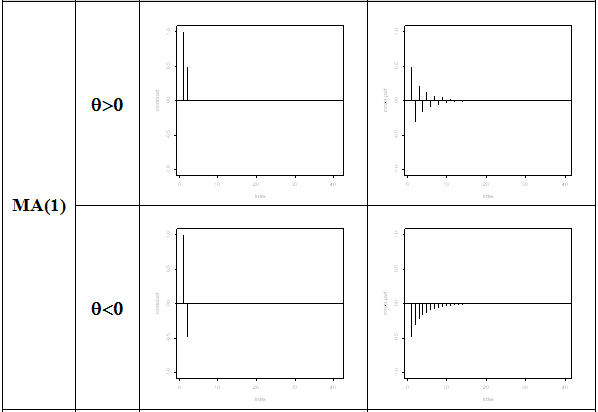

### MA(2) models

**MA(2)** process, considering $\mu = 0$:

$$X_t=(1+\theta_1 B+\theta_2 B^2)Z_t,
\quad Z_t\sim N(0,\sigma_Z^2)$$

Or equivalently:

$$X_t=Z_t+\theta_1 Z_{t-1}+\theta_2
Z_{t-2}, \quad Z_t\sim N(0,\sigma_Z^2)$$

#### **Autocovariance function**:

$$\gamma(0)=E[X_t^2]=E[(Z_t+\theta_1
Z_{t-1}+\theta_2 Z_{t-2})^2]=$$
$$=E[Z_t^2+\theta_1^2 Z_{t-1}^2+\theta_2^2
Z_{t-2}^2+2\theta_1 Z_{t}Z_{t-1}+2\theta_2
Z_{t}Z_{t-2}+2\theta_1\theta_2 Z_{t-1}Z_{t-2}]=$$
$$=E[Z_t^2]+\theta_1^2 E[Z_{t-1}^2]+\theta_2^2
E[Z_{t-2}^2]=$$

$$=(1+\theta_1^2+\theta_2^2)\sigma_Z^2$$

$$\gamma(1)=E[X_t X_{t-1}]=E[(Z_t+\theta_1
Z_{t-1}+\theta_2 Z_{t-2})(Z_{t-1}+\theta_1 Z_{t-2}+\theta_2
Z_{t-3})]=$$
$$=E[Z_tZ_{t-1}]+\theta_1E[Z_tZ_{t-2}]+\theta_2E[Z_tZ_{t-3}]+\dots$$
$$\dots+\theta_1E[Z_{t-1}^2]+\theta_1^2E[Z_{t-1}Z_{t-2}]+\theta_1\theta_2E[Z_{t-1}tZ_{t-3}]+\dots$$
$$\dots+\theta_2E[Z_{t-2}Z_{t-1}]+\theta_1\theta_2E[Z_{t-2}^2]+\theta_2^2E[Z_{t-2}Z_{t-3}]$$

#### **Autocorrelation function**:

$$\rho(1)=\frac{\gamma(1)}{\gamma(0)}=\frac{\theta_1+\theta_1\theta_2}{1+\theta_1^2+\theta_2^2}$$
$$\rho(2)=\frac{\gamma(2)}{\gamma(0)}=\frac{\theta_2}{1+\theta_1^2+\theta_2^2}$$
$$\rho(3)=0$$
$$:\qquad:\qquad:$$
$$\rho(h)=\frac{\gamma(h)}{\gamma(0)}=0 \quad
h>2$$

### MA(q) models

**MA(q)** process, considering $\mu = 0$:

$$X_t=(1+\theta_1 B+\dots+\theta_q
B^q)Z_t, \quad Z_t\sim N(0,\sigma_Z^2)$$

Or equivalently:

$$X_t=Z_t+\theta_1 Z_{t-1}+\dots+\theta_q
Z_{t-q}, \quad Z_t\sim N(0,\sigma_Z^2)$$

#### **Autocovariance function**:

$$\gamma(0)=E[X_t^2]=E[(Z_t+\theta_1
Z_{t-1}+\dots+\theta_q Z_{t-q})^2]=$$
$$=E[Z_t^2+\theta_1^2 Z_{t-1}^2+\dots+\theta_q^2
Z_{t-q}^2]$$
because $E[Z_tZ_s]=0\qquad t\neq s$

$$=(1+\theta_1^2\dots+\theta_q^2)\sigma_Z^2$$

$$\gamma(1)=E[X_t X_{t-1}]=E[(Z_t+\theta_1
Z_{t-1}+\dots+\theta_q Z_{t-q})(Z_{t-1}+\theta_1 Z_{t-2}+\dots\theta_q
Z_{t-q-1})]=$$
$$=(\theta_1+\theta_2\theta_1+\dots+\theta_q\theta_{q-1})\sigma_Z^2$$
$$:\qquad:\qquad:$$
$$\gamma(q)=E[X_t X_{t-q}]=E[(Z_t+\theta_1
Z_{t-1}+\dots+\theta_q Z_{t-q})(Z_{t-q}+\theta_1 Z_{t-q-1}+\dots\theta_q
Z_{t-q-q})]=\theta_q\sigma_Z^2$$
$$\gamma(q+1)=E[X_t X_{t-q-1}]=E[(Z_t+\theta_1
Z_{t-1}+\dots+\theta_q Z_{t-q})(Z_{t-q-1}+\theta_1
Z_{t-q-2}+\dots\theta_q Z_{t-q-q-1})]=0$$
$$\gamma(h)=0 \qquad h>q$$

### ARMA(p,q) models

A times series $\{X_t; t=0, \pm 1, \pm 2, \cdots\}$ is an , ARMA (p,q), if it is stationary and

$$X_t=\phi_1 X_{t-1}+\cdots+\phi_p
X_{t-p}+Z_t+\theta_1 Z_{t-1}+\cdots+\theta_q Z_{t-q}$$

with $\phi_p \neq 0$, $\theta_q \neq 0$ and $\sigma_z^2 > 0$

The parameters $p$ and $q$ are called the autoregressive and the moving average orders, respectively.

If $X_t$ has a nonzero mean $\mu$ and $\alpha=\mu(1-\phi_1-\cdots-\phi_p)$, the model del will be:

$$X_t=\alpha + \phi_1
X_{t-1}+\cdots+\phi_p X_{t-p}+Z_t+\theta_1 Z_{t-1}+\cdots+\theta_q
Z_{t-q}$$

When $q=0$, the model is an AR(p). When $p=0$, the model is a MA(q)

model can be written in concise form as,

$$\phi(B)_pX_t=\theta_q(B)Z_t$$

### ARMA(1,1) models

$$X_t=\phi_1 X_{t-1}+\theta_1
Z_{t-1}+Z_t$$

#### **Autocovariance function**:

$$\gamma(0)=E[X_t^2]=E[(\phi_1X_{t-1}+\theta_1
Z_{t-1}+Z_t)^2]=$$

$$=E[\phi_1^2X_{t-1}^2+\theta_1^2
Z_{t-1}^2+Z_t^2+2\phi_1\theta_1X_{t-1}Z_{t-1}+2\phi_1X_{t-1}Z_t+2\theta_1
Z_{t-1}Z_t]=$$
$$=\phi_1^2E[X_{t-1}^2]+\theta_1^2
E[Z_{t-1}^2]+E[Z_t^2]+2\phi_1\theta_1E[Z_{t-1}^2]+0+0=$$
$$=\phi_1^2\gamma(0)+(1+\theta_1^2+2\phi_1\theta_1)\sigma_Z^2$$

because $E[X_{t-1}Z_{t-1}]=E[Z_{t-1}^2]=\sigma_Z^2\qquad\forall t$

The value of $\gamma(0)$ in this case is:

$$\gamma(0)=\frac{1+\theta_1^2+2\phi_1\theta_1}{1-\phi_1^2}\sigma_Z^2=\left(1+\frac{(\phi_1+\theta_1)^2}{1-\phi_1^2}\right)\sigma_Z^2$$

$$\gamma(1)=E[X_tX_{t-1}]=E[(\phi_1X_{t-1}+\theta_1
Z_{t-1}+Z_t)X_{t-1}]=$$

$$=E[\phi_1X_{t-1}^2+\theta_1
Z_{t-1}X_{t-1}+Z_tX_{t-1}]=$$
$$=\phi_1\gamma(0)+\theta_1
E[Z_{t-1}^2]+0=$$

$$=\phi_1\gamma(0)+\theta_1\sigma_Z^2=\left(\phi_1+\theta_1+\frac{\phi_1(\phi_1+\theta_1)^2}{1-\phi_1^2}\right)\sigma_Z^2$$

$$\gamma(2)=E[X_tX_{t-2}]=E[(\phi_1X_{t-1}+\theta_1
Z_{t-1}+Z_t)X_{t-2}]=$$

$$=E[\phi_1X_{t-1}X_{t-2}+\theta_1
Z_{t-1}X_{t-2}+Z_tX_{t-2}]=\phi_1\gamma(1)$$
$$:\qquad:\qquad:\qquad$$
$$\gamma(h)=\phi_1\gamma(h-1)\qquad
h>1$$

### Identification of ARMA(p,q) models

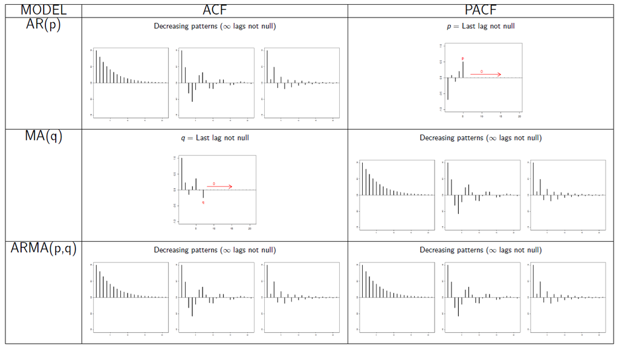